# Predicting Sales related to counterfeit Medicines: Using Decision Tree and Random Forest Model

Executed by Neha More

Nov 3rd, 2017

**PROBLEM STATEMENT**

Use dataset “base_data.csv” to build a model.Variable names are self explanatory.Your task here is to build predictive model for predicting sales figures given other information related to counterfeit medicine selling operations.

**AIM: Use RandomForest and Decision Tress to build your model on train data and compare their performance on test data. Also get the variable importance plot for the model.**

Initial Setup for using decision tree and random forest model:

```r
library(tree)
library(ISLR)
library(randomForest)
library(dplyr)
med=read.csv("base_data.csv") #gives character n num data types.
View(med)
str(med)
```

```
## 'data.frame':    8523 obs. of  12 variables:
##  $ Medicine_ID        : Factor w/ 1557 levels "AAJ32","AAS12",..: 1228 276 782 318 1088 191 505 1543 402 564 ...
##  $ Counterfeit_Weight : num  10.6 7.22 18.8 20.5 10.23 ...
##  $ DistArea_ID        : Factor w/ 10 levels "Area010","Area013",..: 10 4 10 1 2 4 2 6 8 3 ...
##  $ Active_Since       : int  1997 2007 1997 1996 1985 2007 1985 1983 2000 2005 ...
##  $ Medicine_MRP       : num  260.1 58.6 151.9 192.4 64.2 ...
##  $ Medicine_Type      : Factor w/ 16 levels "Analgesics","Antacids",..: 6 1 5 3 7 11 10 10 13 13 ...
##  $ SidEffect_Level    : Factor w/ 2 levels "critical","mild": 2 1 2 1 2 1 1 2 1 1 ...
##  $ Availability_rating: num  0.029 0.0323 0.0298 0.013 0.013 ...
##  $ Area_Type          : Factor w/ 4 levels "CityLimits","DownTown",..: 2 3 2 4 2 3 2 1 2 2 ...
##  $ Area_City_Type     : Factor w/ 3 levels "Tier 1","Tier 2",..: 1 3 1 3 3 3 3 3 2 2 ...
##  $ Area_dist_level    : Factor w/ 4 levels "High","Medium",..: 2 2 2 4 1 2 1 2 4 4 ...
##  $ Counterfeit_Sales  : num  3848 556 2210 845 1108 ...
```

```r
glimpse(med)
```

```
## Observations: 8,523
## Variables: 12
## $ Medicine_ID         <fctr> UJM11, ERM22, NDK33, FKW44, RZH55, DIA66,...
## $ Counterfeit_Weight  <dbl> 10.600, 7.220, 18.800, 20.500, 10.230, 11....
## $ DistArea_ID         <fctr> Area049, Area018, Area049, Area010, Area0...
## $ Active_Since        <int> 1997, 2007, 1997, 1996, 1985, 2007, 1985, ...
## $ Medicine_MRP        <dbl> 260.1092, 58.5692, 151.9180, 192.3950, 64....
## $ Medicine_Type       <fctr> Antipyretics, Analgesics, Antimalarial, A...
## $ SidEffect_Level     <fctr> mild, critical, mild, critical, mild, cri...
## $ Availability_rating <dbl> 0.02904730, 0.03227822, 0.02976008, 0.0130...
## $ Area_Type           <fctr> DownTown, Industrial, DownTown, MidTownRe...
## $ Area_City_Type      <fctr> Tier 1, Tier 3, Tier 1, Tier 3, Tier 3, T...
## $ Area_dist_level     <fctr> Medium, Medium, Medium, Unknown, High, Me...
## $ Counterfeit_Sales   <dbl> 3848.1380, 556.4228, 2210.2700, 845.3800, ...
```

**step 1: Data preparation**

```r
med=med %>%
  na.omit()
glimpse(med)
```

```
## Observations: 7,060
## Variables: 12
## $ Medicine_ID         <fctr> UJM11, ERM22, NDK33, FKW44, RZH55, DIA66,...
## $ Counterfeit_Weight  <dbl> 10.600, 7.220, 18.800, 20.500, 10.230, 11....
## $ DistArea_ID         <fctr> Area049, Area018, Area049, Area010, Area0...
## $ Active_Since        <int> 1997, 2007, 1997, 1996, 1985, 2007, 1985, ...
## $ Medicine_MRP        <dbl> 260.1092, 58.5692, 151.9180, 192.3950, 64....
## $ Medicine_Type       <fctr> Antipyretics, Analgesics, Antimalarial, A...
## $ SidEffect_Level     <fctr> mild, critical, mild, critical, mild, cri...
## $ Availability_rating <dbl> 0.02904730, 0.03227822, 0.02976008, 0.0130...
## $ Area_Type           <fctr> DownTown, Industrial, DownTown, MidTownRe...
## $ Area_City_Type      <fctr> Tier 1, Tier 3, Tier 1, Tier 3, Tier 3, T...
## $ Area_dist_level     <fctr> Medium, Medium, Medium, Unknown, High, Me...
## $ Counterfeit_Sales   <dbl> 3848.1380, 556.4228, 2210.2700, 845.3800, ...
```

divide data into test n train in ration 30:70%

```r
set.seed(3)
s=sample(1:nrow(med),0.7*nrow(med))
med_train=med[s,]
med_test=med[-s,]
```

here response variable is Counterfeit_Sales which is continues numeric variable type. hence problem is of regression type.

**STEP 2: Lets build tree model on train data**

```r
med.tree=tree(Counterfeit_Sales~.-Medicine_ID,data=med_train,na.action = na.exclude)
summary(med.tree)
```

```
##
## Regression tree:
## tree(formula = Counterfeit_Sales ~ . - Medicine_ID, data = med_train,
##     na.action = na.exclude)
## Variables actually used in tree construction:
## [1] "Medicine_MRP" "DistArea_ID"
## Number of terminal nodes:  6
## Residual mean deviance:  1188000 = 5.866e+09 / 4936
## Distribution of residuals:
##     Min.  1st Qu.   Median     Mean  3rd Qu.     Max.
## -3433.00  -614.20   -86.68     0.00   554.80  6308.00
```

terminal nodes:6 mean deviance:1188000

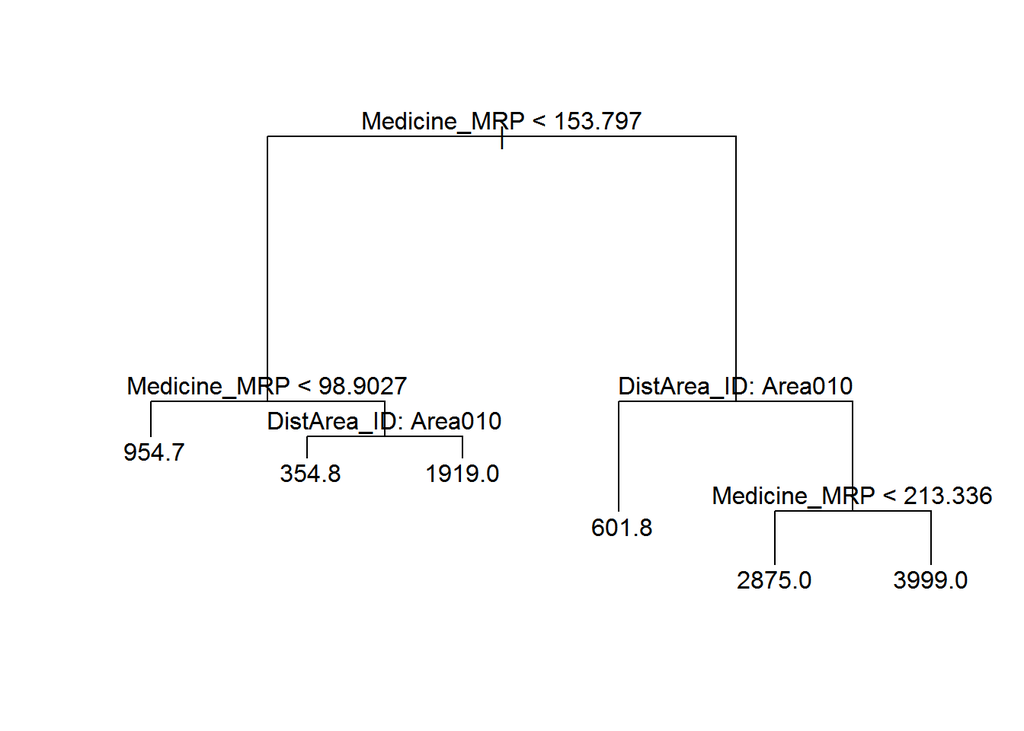

```r
plot(med.tree)
text(med.tree,pretty = 0)
```

**step 3:Predict for test model and find error rmse**

```r
med.pred=predict(med.tree,newdata = med_test)
```

*finding error:RMSE(done for regression variable)*

```r
sum((med_test$Counterfeit_Sales-med.pred)**2) %>%
  sqrt()
```

```
## [1] 49925.79
```

## **error is :49925.79**

**Step 4: Lets prune the tree**

```r
set.seed(3)
cv.med=cv.tree(med.tree)
```

**step 5: lets plot the pruned tree**

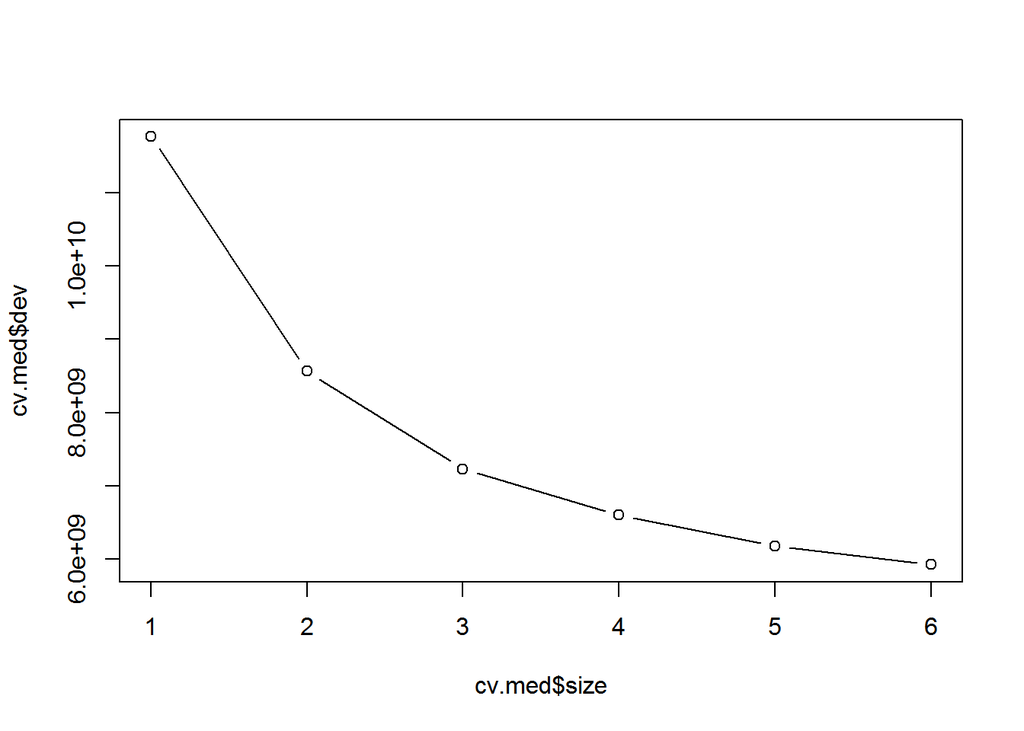

```r
plot(cv.med$size,cv.med$dev,type="b")
```

deviance is smallest for 6 terminal nodes…so no need to create new model

**LETS DO RANDOM FOREST MODEL**

```r
med.rf=randomForest(Counterfeit_Sales~.-Medicine_ID,data=med_train,na.action = na.exclude)#can use do.trace=T
med.rf
```

```
##
## Call:
##  randomForest(formula = Counterfeit_Sales ~ . - Medicine_ID, data = med_train,      na.action = na.exclude)
##                Type of random forest: regression
##                      Number of trees: 500
## No. of variables tried at each split: 3
##
##           Mean of squared residuals: 1193333
##                     % Var explained: 49.83
```

```r
med.rf.pred=predict(med.rf,newdata = med_test)
```

lets find rmse

```r
sum((med_test$Counterfeit_Sales-med.rf.pred)**2) %>%
  sqrt()
```

```
## [1] 49108.53
```

```r
importance(med.rf)
```

```
##                     IncNodePurity
## Counterfeit_Weight      879577035
## DistArea_ID             744926619
## Active_Since            212592958
## Medicine_MRP           5220119648
## Medicine_Type           825332246
## SidEffect_Level         113069585
## Availability_rating     937651678
## Area_Type               687924258
## Area_City_Type          155704105
## Area_dist_level         187139561
```

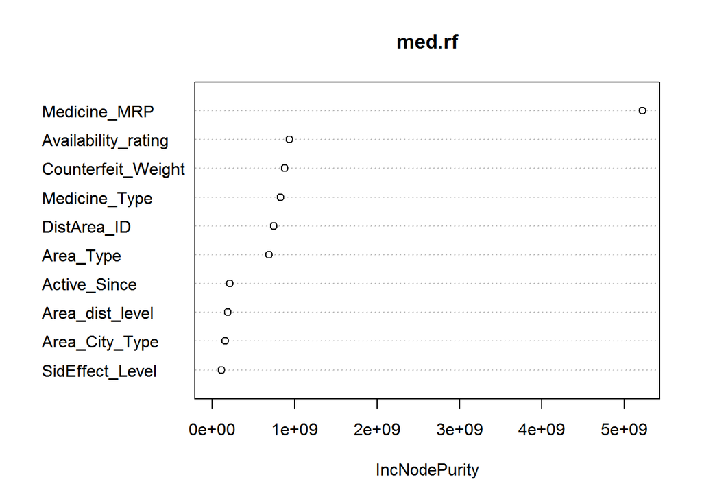

```r
varImpPlot(med.rf)
```

**the mrp and availability rating and counterfeit weight ate the most imp variables contributing towards building of model while side effect level and area city type are least imp variables contributing to build model.**